# Assignment 3

Damaris Montecinos

2024-09-03

## Load Dataset

```r
library(ggplot2)
MxMH_Data <- read.csv("mxmh_survey_results.csv")
head(MxMH_Data, 15)
```

```
##             Timestamp Age         Primary.streaming.service Hours.per.day
## 1  8/27/2022 19:29:02  18                           Spotify           3.0
## 2  8/27/2022 19:57:31  63                           Pandora           1.5
## 3  8/27/2022 21:28:18  18                           Spotify           4.0
## 4  8/27/2022 21:40:40  61                     YouTube Music           2.5
## 5  8/27/2022 21:54:47  18                           Spotify           4.0
## 6  8/27/2022 21:56:50  18                           Spotify           5.0
## 7  8/27/2022 22:00:29  18                     YouTube Music           3.0
## 8  8/27/2022 22:18:59  21                           Spotify           1.0
## 9  8/27/2022 22:33:05  19                           Spotify           6.0
## 10 8/27/2022 22:44:03  18 I do not use a streaming service.           1.0
## 11 8/27/2022 22:51:15  18                           Spotify           3.0
## 12 8/27/2022 23:00:32  19                     YouTube Music           8.0
## 13 8/27/2022 23:04:00  NA                           Spotify           3.0
## 14 8/27/2022 23:12:03  19                           Spotify           2.0
```

[output cut: 113 more lines]

# Clean data

I will be using na.omit() to remove all rows with NA values in the dataset and give the clean dataset a new name

```r
Clean_MxMHData <- na.omit(MxMH_Data)
```

# Histogram for Age per Person in Data

Will create a histogram that shows the Age frequency for every person in the dataset

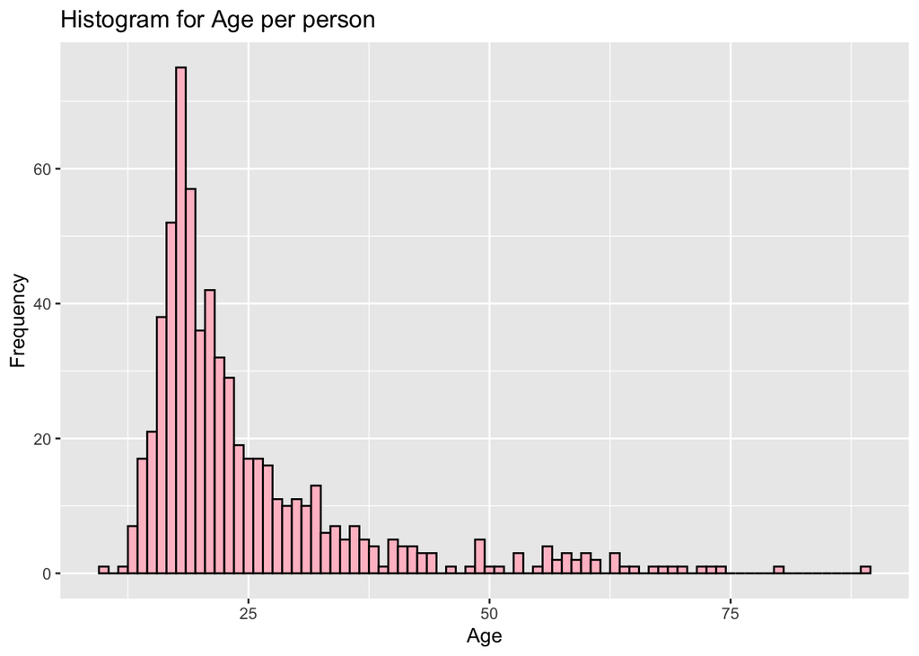

```r
ggplot(Clean_MxMHData, aes(x = Age)) + geom_histogram(binwidth = 1, fill = "pink", color = "black") + labs(title = "Histogram for Age per person", x = "Age", y = "Frequency")
```

# Scatter Plot for Age and Hours Per Day listening to music

Will create a Scatter Plot that shows the correlation between Age and Hours per day someone listens to music

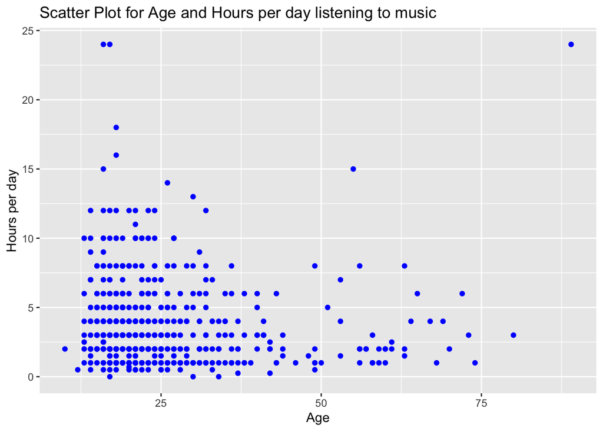

```r
ggplot(Clean_MxMHData, aes(x = Age, y = `Hours.per.day`)) + geom_point(color = "blue") + labs(title = "Scatter Plot for Age and Hours per day listening to music", x = "Age", y = "Hours per day")
```

# Bar Graph based on Music Genres listened to

This bar graph will show the peoples fav genre and count them according to the genre that was picked

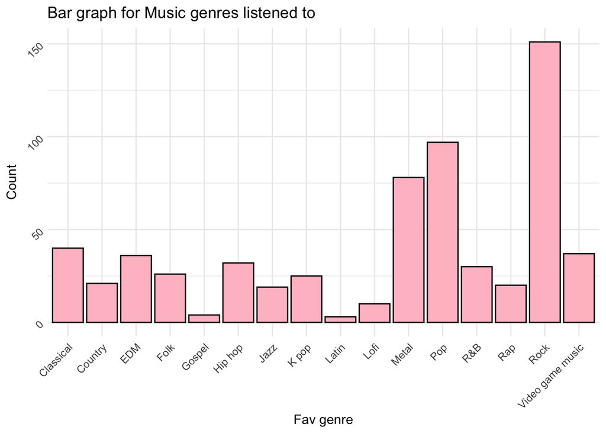

```r
ggplot(Clean_MxMHData, aes(x = `Fav.genre` )) + geom_bar(fill = "pink", color = "black") + labs (title = "Bar graph for Music genres listened to", x = "Fav genre", y = "Count") + theme_minimal() + theme(axis.text = element_text(angle = 45, hjust = 1))
```

# Hypothesis

My Hypothesis is that People with an “Age” less than or equal to 25 have a higher “Hours.per.day” number compared to people older than 25

### Split data into two groups

I will split the data into two groups. one group where age <= 25 and the second group will show where age > 25

```r
Group1 <- Clean_MxMHData$Hours.per.day[Clean_MxMHData$Age <= 25 ]
Group2 <- Clean_MxMHData$Hours.per.day[Clean_MxMHData$Age > 25 ]
```

# Calculate Mean

I will calculate the mean for both groups

```r
MU_Group1 <- mean(Group1)
MU_Group1
```

```
## [1] 3.866441
```

```r
MU_Group2 <- mean(Group2)
MU_Group2
```

```
## [1] 3.337838
```

# T-Test

I will conduct a T-Test to compare the means of the two groups, likely corresponding to the age groups (Age <= 25 and Age > 25) and their respective “Hours.per.day.”

```r
T_TestResults <- t.test(Group1,Group2)
T_TestResults
```

```
##
##  Welch Two Sample t-test
##
## data:  Group1 and Group2
## t = 1.9504, df = 340.23, p-value = 0.05195
## alternative hypothesis: true difference in means is not equal to 0
## 95 percent confidence interval:
##  -0.004485226  1.061692433
## sample estimates:
## mean of x mean of y
##  3.866441  3.337838
```

# Conclusion

While the mean “Hours.per.day” is higher for people with Age <= 25 (3.87) compared to those with Age > 25 (3.34), the difference is not statistically significant at the 0.05 level (p-value = 0.05195). In this case, the p-value shows borderline significance, so it’s unclear whether there is a real difference to support the alternative hypothesis.